# Projetando - designing

## 6 Importando um schema

Para não precisar digitar os comandos de criar as tabelas direto no console, é possível criar um arquivo `.sql` com todos os comandos prontos e simplesmente importá-lo diretamente no SQLite. Para isso:

1. Salve os comandos em um arquivo com a extensão `.sql` na mesma pasta do banco de dados.
2. Acesse o banco de dados pelo terminal e exclua todas as tabelas criadas (para testar).
3. Verifique se todas foram excluídas com o comando `.schema` (não é para aparecer nada).
4. Importe o arquivo usando o comando `.read schema.sql`. Digite `.schema` novamente para ver que todas as tabelas foram criadas.

Agora podemos fazer todas as alterações em um único arquivo.

## 7 Restrições de tabelas

Agora já temos todos os tipos de dados das colunas. No entanto, existem algumas **restrições** entre esses dados que precisamos adicionar. Retomando o conceito de **chaves primárias** e **estrangeiras** visto na aula de relações, temos que toda tabela possui um campo que deve ser uma chave primária:

> A chave primária de uma tabela é um atributo (coluna) que define únicamente os elementos de cada linha da mesma.

Como podemos definir qual é a chave primária de uma tabela? Ainda, vimos também o conveito de **chave estrangeira**: quando a chave primária de uma tabela é usada como um campo em outra tabela. Por exemplo, considerando o modelo de ER do banco de dados, na relação entre as tabelas TRANSACOES_CP e USUÁRIOS, temos que ID_USUARIO é uma chave estrangeira da tabela USUARIOS, ou seja, aqui temos mais uma restrição: não pode existir um ID_USUÁRIO na tabela TRANSACOES_CP que não esteja cadastrado também na tabela USUARIOS.

### 7.1 Chave primária

Podemos definir uma chave primária adicionando o comando `PRIMARY KEY("nome_da_coluna")` no fim da criação da tabela. Considerando a tabela USUARIOS, temos então:

```sql
CREATE TABLE "USUARIOS" (
  "ID" INTEGER,
  "NOME" TEXT,
  "SENHA" TEXT,
  "DATA_CRIACAO" TEXT,
  PRIMARY KEY("ID")
);
```

No entanto, se uma coluna não for especificada como chave primária, o próprio SQLite faz a criação de uma chamada `row ID``.

### 7.2 Chave estrangeira

Para adicionar a chave estrangeira, é necessário também informar o seu nome na tabela original, ou seja, referenciar o nome da coluna orignal. A sintaxe é `FOREIGN KEY("nome_da_coluna_tabela_atual") REFERENCES "tabela_original"("nome_da_coluna_tabela_original")`. Por exemplo, considerando a tabela TRANSACOES_CP, temos que a coluna ID_USUARIO é uma referência a coluna ID da tabela USUARIOS, portanto o comando fica da seguinte forma:

```sql
CREATE TABLE "TRANSACOES_CP" (
  "ID" INTEGER,
  "ID_USUARIO" INTEGER,
  "TIPO" INTEGER,
  "VALOR" REAL,
  "DATA" TEXT,
  FOREIGN KEY("ID_USUARIO") REFERENCES "USUARIOS"("ID")
);
```

EXERCÍCIO: Atualize o diagrama ER com todas as restrições de chaves primárias e estrangeiras das tabelas (coloque ao lado das colunas o tipo de chave).

**RESPOSTA**

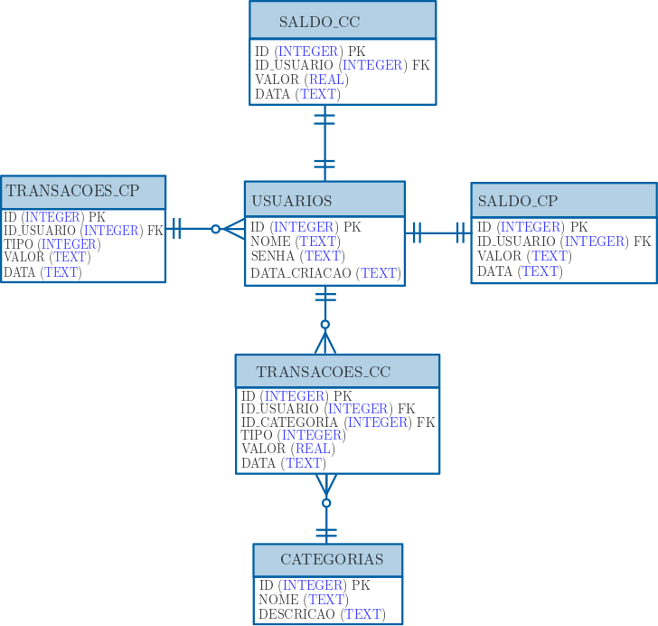

ER - Restrições chaves

EXERCÍCIO: Atualize as tabelas (schema) do banco de dados com as restrições de chaves primárias e estrangeiras (exclua todas as tabelas já criadas usando o comando DROP TABLE )

**RESPOSTA**

```sql
CREATE TABLE "USUARIOS" (
  "ID" INTEGER,
  "NOME" TEXT,
  "SENHA" TEXT,
  "DATA_CRIACAO" TEXT,
  PRIMARY KEY("ID")
);

CREATE TABLE "SALDO_CC" (
    "ID" INTEGER,
    "ID_USUARIO" INTEGER,
    "VALOR" REAL,
    "DATA_ATUALIZACAO" TEXT,
    PRIMARY KEY("ID"),
    FOREIGN KEY("ID_USUARIO") REFERENCES "USUARIOS"("ID")
);

CREATE TABLE "SALDO_CP" (
    "ID" INTEGER,
    "ID_USUARIO" INTEGER,
    "VALOR" REAL,
    "DATA_ATUALIZACAO" TEXT,
    PRIMARY KEY("ID"),
    FOREIGN KEY("ID_USUARIO") REFERENCES "USUARIOS"("ID")
);

CREATE TABLE "TRANSACOES_CC" (
  "ID" INTEGER,
  "ID_USUARIO" INTEGER,
  "ID_CATEGORIA" INTEGER,
  "TIPO" INTEGER,
  "VALOR" REAL,
  "DATA" TEXT,
  PRIMARY KEY("ID"),
  FOREIGN KEY("ID_USUARIO") REFERENCES "USUARIOS"("ID"),
  FOREIGN KEY("ID_CATEGORIA") REFERENCES "CATEGORIAS"("ID")
);

CREATE TABLE "TRANSACOES_CP" (
  "ID" INTEGER,
  "ID_USUARIO" INTEGER,
  "TIPO" INTEGER,
  "VALOR" REAL,
  "DATA" TEXT,
  PRIMARY KEY("ID"),
  FOREIGN KEY("ID_USUARIO") REFERENCES "USUARIOS"("ID"),
);

CREATE TABLE "CATEGORIAS" (
  "ID" INTEGER,
  "NOME" TEXT,
  "DESCRICAO" TEXT,
  PRIMARY KEY("ID")
);
```

## 8 Restrições de colunas

As restrições de colunas se aplicam a colunas específicas de uma tabela, por exemplo, podemos definir que uma determinada coluna não possa ter valores nulos. Existem quatro tipo de restrições de colunas em SQLite:

| Restrição | Definição |
| --- | --- |
| CHECK | Permite verificar alguma condição (ex: verficar se um valor é maior do que 0) |
| DEFAULT | É um valor adicionado como padrão, quando nada é inserido no campo |
| NOT NULL | Não é possível deixar valores inseridos |
| UNIQUE | Garante que cada linha da coluna é única |

Vamos verificar como usar o valor **NOT NULL**. Podemos definir que a coluna NOME da tabela USUARIOS não pode ficar sem preenchimento. Usamos a sintaxe `NOT NULL` depois da definição da classe de dados:

```sql
CREATE TABLE "USUARIOS" (
  "ID" INTEGER,
  "NOME" TEXT NOT NULL,
  "SENHA" TEXT,
  "DATA_CRIACAO" TEXT,
  PRIMARY KEY("ID")
);
```

Será que é necessário, então, adicionar a condição **NOT NULL** para todas as chaves primárias, dado que por definição elas devem existir e não podem se repetir?

Isso poderia ser feito para fins de completude, mas não é necessário. Ao inserirmos a restrição de tabela `PRIMARY KEY` uma série de restrições de coluna já são criadas, como `NOT NULL` e `UNIQUE`. O mesmo se aplica a chaves estrangeiras: como uma chave estrangeria é uma chave primária de outra tabela, a mesma deve existir (na tabela original).

Podemos definir que o campo NOME em categorias deve existir, e não pode se repetir:

```sql
CREATE TABLE "CATEGORIAS" (
  "ID" INTEGER,
  "NOME" TEXT NOT NULL UNIQUE,
  "DESCRICAO" TEXT,
  PRIMARY KEY("ID")
);
```

EXERCÍCIO: Altere o `schema` do banco de dados com as restrições de coluna que achar necessárias (verifique como usar `DEFAULT` e `CHECK`). Sugestões: 1. Datas como default de da data atual. 2. Cerificar se valores monetários são >= 0. 3. Garantir que o TIPO de transações seja somente 0 ou 1 (saída ou entrada).

```sql
CREATE TABLE "USUARIOS" (
  "ID" INTEGER,
  "NOME" TEXT NOT NULL,
  "SENHA" TEXT NOT NULL,
  "DATA_CRIACAO" TEXT DEFAULT(CURRENT_TIMESTAMP),
  PRIMARY KEY("ID")
);

CREATE TABLE "SALDO_CC" (
    "ID" INTEGER,
    "ID_USUARIO" INTEGER,
    "VALOR" REAL CHECK("VALOR" >= 0),
    "DATA_ATUALIZACAO" TEXT DEFAULT(CURRENT_TIMESTAMP),
    PRIMARY KEY("ID"),
    FOREIGN KEY("ID_USUARIO") REFERENCES "USUARIOS"("ID")
);

CREATE TABLE "SALDO_CP" (
    "ID" INTEGER,
    "ID_USUARIO" INTEGER,
    "VALOR" REAL CHECK("VALOR" >= 0),
    "DATA_ATUALIZACAO" TEXT DEFAULT(CURRENT_TIMESTAMP),
    PRIMARY KEY("ID"),
    FOREIGN KEY("ID_USUARIO") REFERENCES "USUARIOS"("ID")
);

CREATE TABLE "TRANSACOES_CC" (
  "ID" INTEGER,
  "ID_USUARIO" INTEGER,
  "ID_CATEGORIA" INTEGER,
  "TIPO" INTEGER NOT NULL CHECK("TIPO" IN (0,1)),
  "VALOR" REAL CHECK("VALOR" >= 0),
  "DATA" TEXT DEFAULT(CURRENT_TIMESTAMP),
  PRIMARY KEY("ID"),
  FOREIGN KEY("ID_USUARIO") REFERENCES "USUARIOS"("ID"),
  FOREIGN KEY("ID_CATEGORIA") REFERENCES "CATEGORIAS"("ID")
);

CREATE TABLE "TRANSACOES_CP" (
  "ID" INTEGER,
  "ID_USUARIO" INTEGER,
  "TIPO" INTEGER NOT NULL CHECK("TIPO" IN (0,1)),
  "VALOR" REAL CHECK("VALOR" >= 0),
  "DATA" TEXT DEFAULT(CURRENT_TIMESTAMP),
  PRIMARY KEY("ID"),
  FOREIGN KEY("ID_USUARIO") REFERENCES "USUARIOS"("ID")
);

CREATE TABLE "CATEGORIAS" (
  "ID" INTEGER,
  "NOME" TEXT NOT NULL UNIQUE,
  "DESCRICAO" TEXT DEFAULT "-",
  PRIMARY KEY("ID")
);
```